# Monitor socioeconómico — La Rioja

Prototipo de monitoreo de indicadores · Fundar

Fundar

septiembre 2026

# Introducción

Este documento es el **prototipo de monitor socioeconómico** elaborado en el marco de la consultoría de fortalecimiento de capacidades de la Secretaría de Comunicación y Planificación Pública del Gobierno de La Rioja (Dirección General de Planificación y Monitoreo de Políticas Públicas). Su finalidad es apoyar el **análisis, la interpretación y la comunicación** de información basada en datos para la toma de decisiones y la comunicación institucional.

El monitor reúne indicadores de interés provincial, con gráficos comparativos y textos de lectura. Se construyó de forma conjunta entre el equipo provincial y Fundar, tomando como referencia metodológica y de fuentes a [Argendata](https://argendata.fund.ar/).

### Organización

El Monitor se estructura en tres bloques temáticos: **Macroeconomía**, **Desarrollo** y **Trabajo e ingresos**. Cada indicador incluye una pregunta guía, un análisis, gráficos y una **ficha metodológica** (definición, fuente, cálculo y limitaciones). Dichas fichas se listan asimismo al final del documento y en el índice. La organización temática es consistente con las categorías de [Argendata](https://argendata.fund.ar/) correspondientes a esos tres bloques.

### Corte territorial

Con excepción de los casos en que se indique lo contrario (por ejemplo, cuando la fuente es la EPH continua y el dato corresponde al aglomerado capital), las series se elaboran para tres agregados:

- **La Rioja:** la provincia (o el aglomerado capital, cuando la fuente es EPH continua).
- **NOA-Resto:** Catamarca, Jujuy, Salta, Santiago del Estero y Tucumán (NOA sin La Rioja).
- **Resto país:** las demás jurisdicciones del país (excluye La Rioja y el NOA-Resto).

### Actualización

El código y las instrucciones para la actualización de datos y gráficos se encuentran disponibles en el repositorio (`README.md`).

# Macroeconomía

Este bloque analiza el **tamaño y la dinámica** de la economía provincial y el **financiamiento y cierre** de las cuentas públicas. Incluye el PBG (crecimiento del valor agregado) y las finanzas provinciales (peso de la recaudación tributaria directa frente a la coparticipación y otras transferencias, y resultado fiscal de la APNF). El resultado fiscal de La Rioja se expresa como **% del PBG nominal** provincial; no se construye comparación regional en ese indicador por ausencia de PBG nominal homogéneo para el resto de las provincias.

## PIB / PBG provincial

**¿Cómo evolucionó el producto bruto de La Rioja?** Ficha metodológica.

El crecimiento económico de una provincia se aproxima con la evolución de su producto: mayor actividad suele asociarse a más empleo, ingresos y capacidad fiscal para sostener servicios públicos ([Argendata — Crecimiento](https://argendata.fund.ar/topico/crecimiento/)). En Argentina, una proporción elevada de la producción se concentra en pocas jurisdicciones; el seguimiento del PBG provincial es útil para evaluar si La Rioja evoluciona en sintonía con el NOA-Resto y el resto del país, o si su dinámica se diferencia de esos agregados.

**Metodología.** En el Monitor se utiliza el **VAB provincial a precios constantes de 2004** (CEPAL / Ministerio de Economía), que aproxima el PBG. Cada serie se expresa como **índice 2004 = 100**: 100 es el nivel de 2004; un valor de 127,7 en 2024 indica que el producto real creció aproximadamente 28% en ese lapso. El índice permite comparar **dinámicas**, no el tamaño absoluto del producto. El peso industrial se analiza en la sección siguiente.

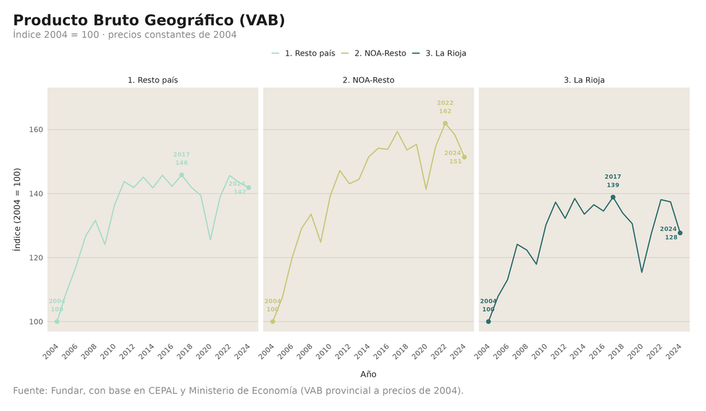

**Lectura de largo plazo**

- Entre 2004 y 2024, el producto real de La Rioja creció +27,7%. En el mismo período, el NOA-Resto creció +51,4% y el resto del país +41,8%.
- En otras palabras: partiendo de la misma base (índice 2004 = 100), en 2024 La Rioja llegó a 127,7, el NOA-Resto a 151,4 y el resto del país a 141,8.

**Lectura reciente**

- En el último año disponible (2023→2024), La Rioja cayó 7,1% (NOA-Resto -4,4%; resto del país -1,1%).
- Mirando un tramo más reciente (desde 2019, previo a la pandemia), La Rioja retrocedió 2,2%; el NOA-Resto retrocedió 2,6% y el resto del país creció +1,7%.
- La caída interanual de 2024 fue más marcada en La Rioja que en los agregados de comparación.

#### PBG per cápita

Además de la **dinámica del producto total**, el VAB **por habitante** permite evaluar la posición relativa de La Rioja frente al NOA-Resto y al resto del país cuando cambia la población. Se expresa en **pesos constantes de 2004** por persona (volumen real). La serie comparable comienza en **2010** (limitación de la proyección poblacional utilizada), con índice 2010 = 100.

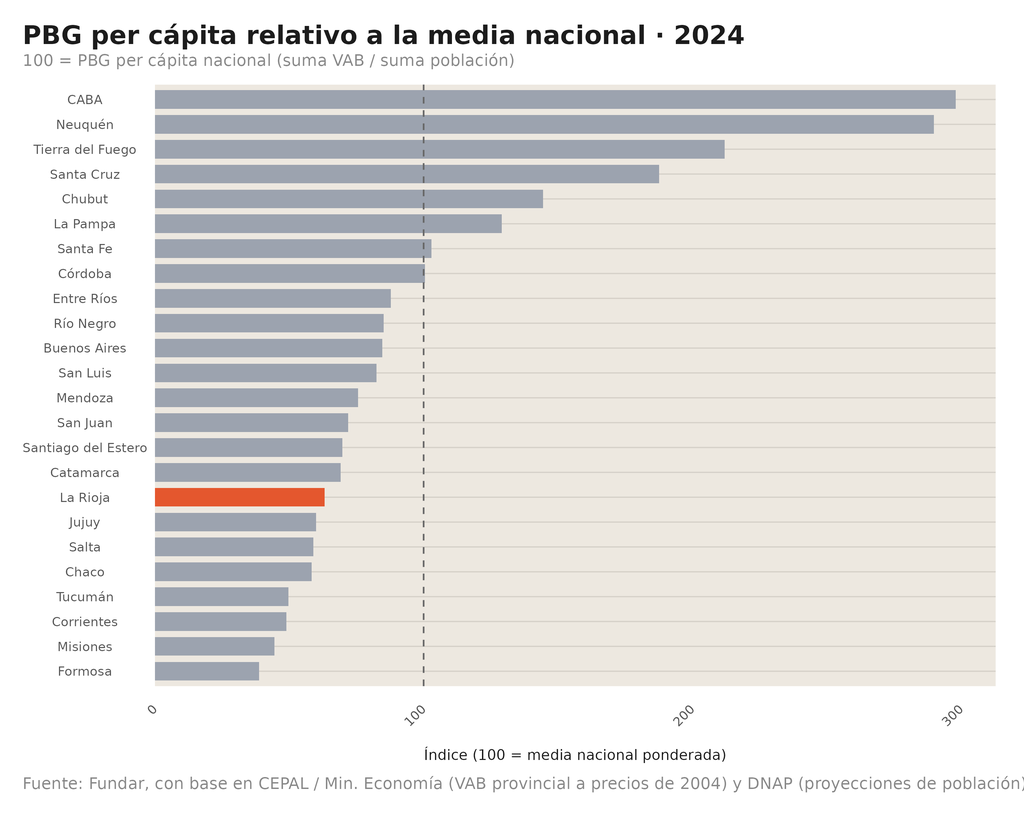

**Nivel (2024)**

- En 2024, el PBG por habitante de La Rioja fue 8.009 pesos de 2004 por persona (NOA-Resto 7.479; resto del país 13.434).
- Respecto del PBG per cápita nacional (índice 100, ponderado por población), La Rioja registra un índice de 63 (en 2010 el índice era 69).

**Lectura de largo plazo (2010→2024)**

- Entre 2010 y 2024, el PBG per cápita real de La Rioja cayó 16,4%. En el mismo período, el NOA-Resto cayó 8,4% y el resto del país cayó 7,8%.
- La serie per cápita comienza en 2010 (índice 2010 = 100). En 2024, La Rioja registra un índice de 83,6; el NOA-Resto, de 91,6; y el resto del país, de 92,2.

**Lectura reciente**

- En el último año (2023→2024), el PBG per cápita de La Rioja cayó 7,5% (NOA-Resto -4,7%; resto del país -1,3%).
- Desde 2019 (previo a la pandemia), La Rioja retrocedió 5,5%; el NOA-Resto retrocedió 8,1% y el resto del país retrocedió 0,9%.
- La caída interanual del PBG per cápita fue más fuerte en La Rioja que en los agregados de comparación.

#### Ranking provincial

**¿Cómo evolucionó la posición relativa de La Rioja entre las 24 jurisdicciones?** Además del nivel y la variación, interesa el ordenamiento provincial: el siguiente bump chart ordena a las 24 provincias por PBG per cápita (pesos constantes de 2004) en cada año de la serie 2010-2024 y muestra el recorrido de cada una. La Rioja y las provincias del NOA-Resto se destacan en tonos de verde (La Rioja, en el más oscuro); el resto, en gris.

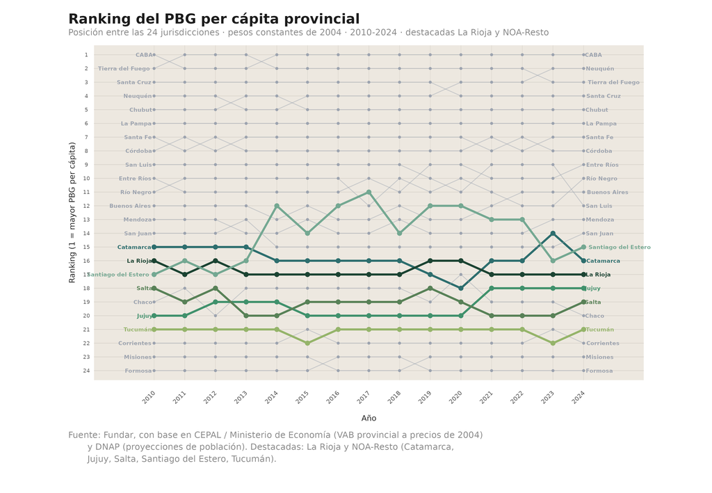

### Ficha metodológica

- **¿Qué mide?** Valor agregado bruto provincial (VAB) a precios básicos y constantes de 2004, que aproxima el Producto Bruto Geográfico (PBG) de La Rioja.
- **¿Para qué sirve?** Seguir la dinámica de la economía provincial frente al NOA-Resto y al resto del país. Permite comparar crecimiento real sin efecto de la inflación.
- **¿Qué nos dice?**
  - *Si sube:* mayor actividad / producto en la jurisdicción (a precios de 2004).
  - *Si baja:* contracción del VAB real.
- **Comportamiento esperado:** indicador macro anual, cíclico; sensible a shocks macro, sectoriales y demográficos.
- **Unidad de medida:** millones de pesos constantes de 2004; índice 2004 = 100 (dinámica relativa).
- **Fórmula de cálculo:** PBG ≈ suma del VAB por ramas (52 sectores CEPAL). Agregados regionales = suma de VAB provincial. Índice $100 \times VAB_t / VAB_{2004}$ (dentro de cada grupo).
- **Fuente de datos oficial:** CEPAL / Ministerio de Economía — [Desagregación provincial del VAB, base 2004](https://repositorio.cepal.org/server/api/core/bitstreams/539fcce5-8977-4061-a222-fbfd7358a35f/content). Scripts: `15_prep_pbg.R`, `15_pbg.R`.
- **Frecuencia de actualización:** anual (cuando publiquen nueva versión del Excel; serie 2004–2024 en el raw actual).
- **Limitaciones:** VAB a precios básicos (no PIB a precios de mercado). El índice compara dinámicas, no tamaño absoluto. Estimaciones CEPAL homogéneas para comparar provincias; no sustituyen el PBG de la estadística provincial. NOA-Resto y resto país son sumas; La Rioja es una sola jurisdicción.

## Recursos propios / recursos totales

**¿Qué parte del financiamiento tributario de La Rioja recauda la provincia de manera directa?** Ficha metodológica.

Argentina es un país federal: Nación, provincias y municipios **comparten** facultades y recursos tributarios. Las provincias suelen ejecutar una porción del gasto mayor a la que recaudan de forma directa; la coparticipación federal y otras transferencias cubren gran parte de esa brecha. Conviene precisar el alcance del indicador: los recursos coparticipables **son de las provincias** en el esquema federal; lo que distingue a esta métrica no es la “propiedad” del recurso, sino **quién lo recauda de manera directa**.

El indicador no constituye, por sí solo, un juicio sobre la “calidad” de la gestión: aproxima el peso de la **recaudación tributaria directa** de la provincia dentro del financiamiento tributario considerado (TOP + RON).

**Metodología.** Se define TOP como los recursos tributarios de origen provincial (los que la provincia recauda de manera directa) y RON como los recursos de origen nacional (coparticipación y transferencias tributarias que la provincia no recauda directamente). El indicador se calcula como TOP / (TOP + RON). El agregado regional se obtiene sumando montos y calculando luego el ratio. Fuente: Ministerio de Economía.

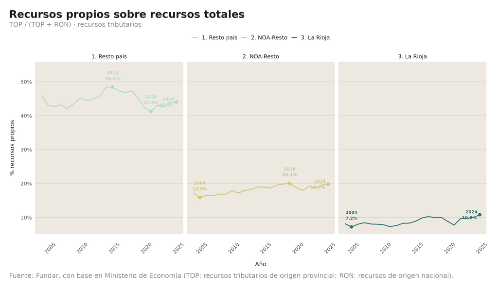

- En 2024, La Rioja recaudó de manera directa el 10,8% del financiamiento tributario considerado (suma TOP + RON).
- Ese nivel quedó por debajo del NOA-Resto (19,9%) y del resto del país (44,0%): mayor peso relativo de la coparticipación y transferencias (recursos que la provincia no recauda de forma directa).
- Respecto de 2023 (10,0%), el indicador subió 0,8 puntos porcentuales. Al inicio de la serie comparable (2003) era 8,2%.

### Ficha metodológica

- **¿Qué mide?** La participación de los recursos tributarios que la provincia **recauda de manera directa** (TOP) sobre la suma de TOP y recursos de origen nacional (RON: coparticipación y transferencias tributarias). “Propios” se usa en este Monitor como sinónimo operativo de recaudación directa, no como juicio sobre la titularidad federal del recurso: los recursos coparticipables son de las provincias; lo que no hacen es recaudarlos directamente.
- **¿Para qué sirve?** Aproxima el peso de la recaudación tributaria directa en el financiamiento tributario considerado (TOP + RON).
- **¿Qué nos dice?**
  - *Si sube:* mayor peso de lo recaudado de forma directa por la provincia.
  - *Si baja:* mayor peso relativo de RON (coparticipación y transferencias).
- **Comportamiento esperado:** indicador estructural; cambios graduales salvo reformas fiscales o shocks en transferencias.
- **Unidad de medida:** porcentaje (%).
- **Fórmula de cálculo:** TOP / (TOP + RON) × 100. Agregado regional = suma de montos, luego ratio. *(El cálculo no cambia; solo se precisa el wording.)*
- **Fuente de datos oficial:** Ministerio de Economía — [TOP](https://www.argentina.gob.ar/sites/default/files/serie_top_1984_2024_1.xlsx), [RON](https://www.argentina.gob.ar/sites/default/files/serie_ron_2003_2025.xlsx). Scripts: `16_prep_recursos_propios.R`, `16_recursos_propios.R`.
- **Frecuencia de actualización:** anual (intersección disponible ~2003–2024).
- **Limitaciones:** solo recursos tributarios TOP + RON; no cubre endeudamiento ni otros ingresos. Un ratio bajo no implica por sí solo mala gestión: refleja también el diseño del federalismo fiscal y la estructura productiva provincial. No es equivalente a ingresos totales APNF.

## Resultado fiscal (APNF)

**¿Los ingresos cubren los gastos en la provincia?** Ficha metodológica.

Este indicador **complementa** el de recursos propios: no se limita a identificar el origen de los recursos, sino que permite evaluar si las cuentas de la Administración Pública No Financiera (APNF) provincial cierran, comparando el resultado con el **tamaño de la economía** (PBG nominal).

En la misma fuente (ejecuciones presupuestarias de la APNF) se distinguen **dos lecturas**:

- **Resultado financiero** = ingresos totales − gastos totales. Los gastos totales **incluyen el pago de intereses** de la deuda. Constituye el cierre “completo” de las cuentas en esa definición.
- **Resultado primario** = ingresos totales − gastos primarios. Los gastos primarios corresponden al gasto **sin intereses**. Permite observar si la provincia cubre su gasto de funcionamiento y de política pública **antes** de afrontar el servicio de la deuda.

Por esa razón, ambos resultados **pueden diferir**: en ocasiones el primario resulta menos negativo (o positivo) y el financiero más negativo, debido a que los intereses inciden en el total.

**Metodología.** Ambos ratios se calculan como resultado / **PBG nominal** de La Rioja (valores corrientes a precios básicos; fuente: Dirección General de Estadísticas y Censos de la provincia). El numerador proviene de las ejecuciones APNF (Ministerio de Economía). La serie cubre la intersección de años disponibles en ambas fuentes. **No se presenta comparación con NOA-Resto ni con el resto del país** en este indicador: no se dispone de una serie de PBG nominal homogénea para las demás provincias. El PBG del Monitor a precios constantes de 2004 (CEPAL) **no** se utiliza como denominador.

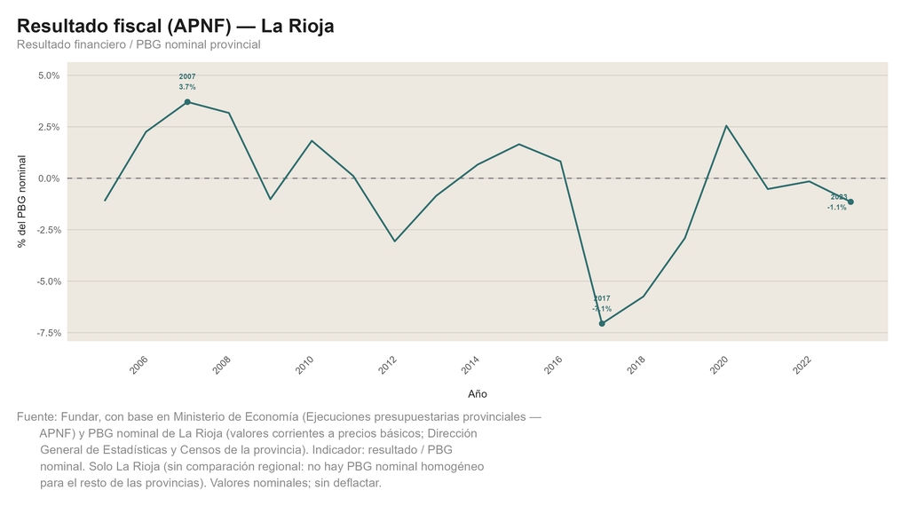

- En 2023, La Rioja cerró con déficit financiero equivalente al 1,1% del PBG nominal.
- Un año antes (2022), había cerrado con déficit del 0,2% del PBG nominal.
- El resultado primario (gasto sin intereses) registró superávit del 0,3% del PBG nominal: permite ver el cierre antes del pago de intereses.
- La serie publicada corresponde a 2005–2023 (intersección entre ejecuciones APNF y PBG nominal provincial).

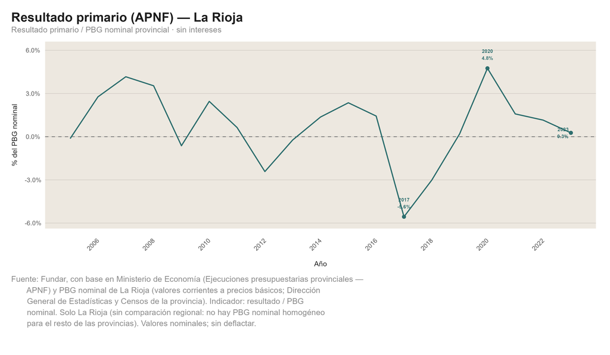

### Ficha metodológica

- **¿Qué mide?** Dos saldos de la Administración Pública No Financiera (APNF) de La Rioja, expresados como porcentaje del **PBG nominal** provincial:
  - *Financiero:* ingresos totales − gastos totales (**incluye** el pago de intereses).
  - *Primario:* ingresos totales − gastos primarios (**excluye** intereses).
- **¿Para qué sirve?** Permite evaluar el resultado fiscal en relación con el tamaño de la economía provincial y distinguir el efecto del servicio de la deuda.
- **¿Qué nos dice?**
  - *Ratio positivo:* superávit en la definición correspondiente.
  - *Ratio negativo:* déficit en la definición correspondiente.
  - *Primario superior al financiero:* parte de la diferencia se explica por el pago de intereses.
- **Comportamiento esperado:** serie anual en valores nominales (sin deflactar). Varía con el ciclo económico y la ejecución presupuestaria.
- **Unidad de medida:** porcentaje del PBG nominal (%).
- **Fórmula de cálculo:** resultado financiero / PBG nominal; resultado primario / PBG nominal. PBG en millones de $ = Total de la hoja Corrientes (miles de $) / 1000.
- **Fuente de datos oficial:** numerador — Ministerio de Economía (ejecuciones presupuestarias APNF). Denominador — PBG nominal de La Rioja (valores corrientes a precios básicos; **Dirección General de Estadísticas y Censos de la provincia de La Rioja**; `data/raw_data/pbg/PBG_cuadros_generales_sectoreales_final_sept_2026.xlsx`). Scripts: `17_prep_resultado_fiscal.R`, `17_resultado_fiscal.R`.
- **Frecuencia de actualización:** anual. La actualización del PBG nominal corresponde a la Dirección General de Estadísticas y Censos de la provincia; la del APNF, al Excel del Ministerio de Economía.
- **Limitaciones:** la APNF no representa al sector público consolidado en su totalidad. El ratio no sustituye un análisis de deuda, de caja ni de calidad del gasto. No debe confundirse con TOP/RON (recursos tributarios). **No utilizar** el PBG CEPAL (precios constantes de 2004) como denominador. **Solo La Rioja:** no se presenta comparación con NOA-Resto ni con el resto del país ante la ausencia de PBG nominal homogéneo para las demás provincias. La serie se limita al último año con ambas fuentes disponibles.

# Desarrollo

Este bloque analiza la **estructura productiva**, la **inserción** de la provincia en el comercio exterior y dimensiones del **bienestar**. La estructura productiva comprende el entramado de actividades que generan bienes y servicios en un territorio, e incide en las posibilidades de crecimiento y diversificación económica. En el Monitor se abordan, a escala provincial y comparada, la composición del PBG (industria y rubros), las exportaciones, la cantidad de empresas formales, el nivel educativo y la trayectoria escolar, y la pobreza por NBI.

## % del PBG industrial

**¿Qué peso tiene la industria en el PBG?** Ficha metodológica.

En Argentina la industria manufacturera es el principal componente de los bienes dentro del PIB nacional (del orden del 19% del PIB en la lectura de Argendata). A escala provincial el peso cambia mucho: en el centro suele ser más alto; en el norte, en promedio, más bajo.

**Metodología.** El indicador mide la participación de la industria manufacturera (letra D, CIIU Rev. 3) en el VAB regional a precios de 2004 — misma fuente que el PBG del Monitor— para situar a La Rioja frente al NOA-Resto y al resto del país.

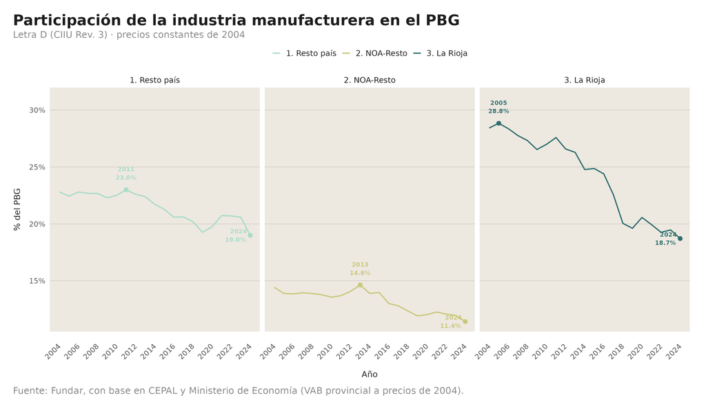

- En 2024, la industria representó el 18,7% del PBG de La Rioja (11,4% en NOA-Resto; 19,0% en el resto del país).

### Ficha metodológica

- **¿Qué mide?** Participación de la industria manufacturera (letra D, CIIU Rev. 3) en el VAB / PBG regional a precios de 2004.
- **¿Para qué sirve?** Ver si la economía provincial se industrializa, se estabiliza o se tertiariza.
- **¿Qué nos dice?**
  - *Si sube:* mayor peso industrial en el producto (relativo a otros sectores).
  - *Si baja:* menor peso industrial (puede ser caída industrial o mayor crecimiento de otros sectores).
- **Comportamiento esperado:** indicador estructural; cambios graduales, también afectado por ciclos sectoriales.
- **Unidad de medida:** porcentaje (%) del VAB provincial (precios constantes de 2004).
- **Fórmula de cálculo:** peso industrial = (VAB industria manufacturera / VAB total) × 100.
- **Fuente de datos oficial:** CEPAL / Ministerio de Economía (misma fuente PBG). Scripts: `15_prep_pbg.R`, `15_pbg.R`.
- **Frecuencia de actualización:** anual.
- **Limitaciones:** share ≠ nivel absoluto de industria. No desagrega ramas industriales. Precios constantes 2004. No confundir caída del share con caída absoluta del VAB industrial: puede bajar el peso porque otros sectores crecieron más.

## ¿Cómo se compone el PBG por rubro?

*Complemento analítico* (misma fuente CEPAL): participación sectorial del PBG a precios de 2004 en el último año disponible. Permite ver qué rubros explican el producto provincial, al estilo de la lectura estructural de [Argendata](https://argendata.fund.ar/topico/estructura-productiva/).

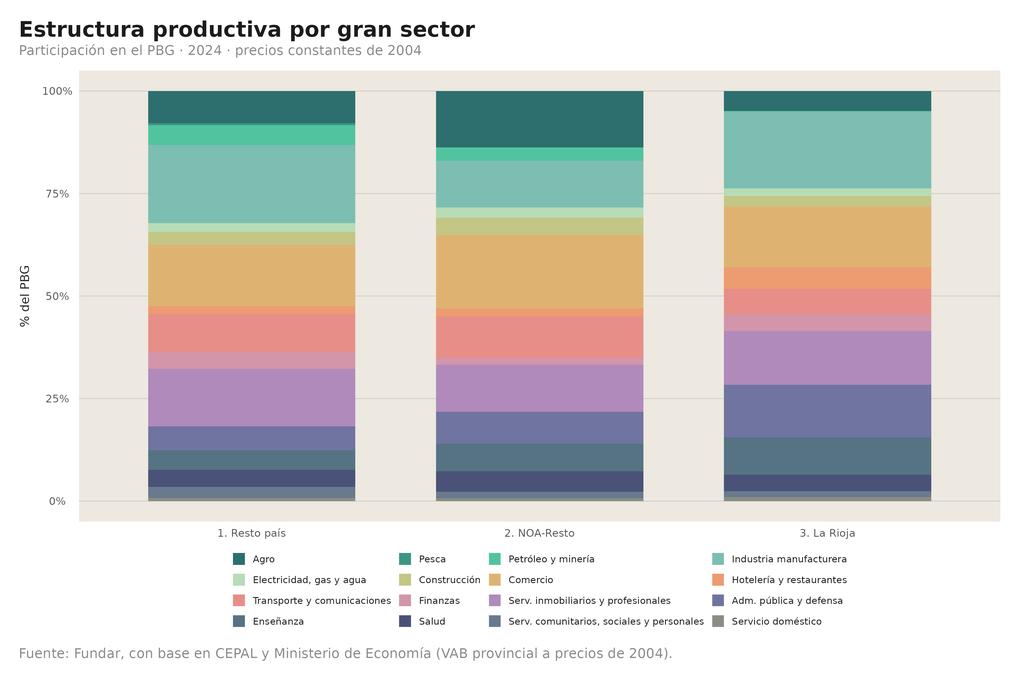

- En 2024, los cuatro rubros con mayor peso en La Rioja fueron: Industria manufacturera (18,7%); Comercio (14,8%); Serv. inmobiliarios y profesionales (13,1%); Adm. pública y defensa (12,9%).

## Exportaciones

**¿Cuánto exporta La Rioja?** Ficha metodológica.

Las exportaciones de bienes son un canal clave de inserción externa, pero su peso y su composición varían mucho entre provincias. A escala nacional, la canasta argentina se concentra en productos agropecuarios y derivados de recursos naturales; a escala provincial, esa inserción es heterogénea. En el NOA, por ejemplo, jurisdicciones con fuerte peso minero o cerealero contrastan con perfiles más manufactureros o agroindustriales, en parte ligados a trayectorias de promoción industrial (como en La Rioja). El indicador que sigue permite leer cuánto exporta la provincia, cómo evoluciona frente a la región y el país, y en qué se concentra esa canasta.

**Metodología.** El indicador mide las exportaciones de la provincia, entendidas como su capacidad para vender bienes al resto del mundo. La fuente es Origen Provincial de las Exportaciones (OPEX–INDEC), en millones de dólares. Los montos se agregan por **suma** (no promedio) en tres grupos: La Rioja, el resto del NOA (Catamarca, Jujuy, Salta, Santiago del Estero y Tucumán) y el resto del país. Los períodos recientes pueden ser provisionales.

A fin de evitar distorsiones de escala: en valores absolutos, La Rioja exporta en el orden de los cientos de millones de dólares; el resto del NOA, miles de millones; y el resto del país, decenas de miles de millones. Un gráfico en millones de dólares con eje compartido **reduce visualmente** la serie riojana hasta tornar difícil su lectura; los paneles con ejes libres muestran cada trayectoria, pero no permiten evaluar con claridad si la provincia evoluciona por encima o por debajo de la región. Por ello se utiliza un **índice 2015 = 100** (dinámica relativa), complementado con la **participación** sobre la suma OPEX de las 24 jurisdicciones y con la **composición** por subrubros (treemap).

**¿Qué nos dice el último dato (2025)?**

- Durante 2025, La Rioja registró exportaciones por 163 millones de USD, el 0,19% de la suma nacional OPEX (aproximadamente 85.341 millones de USD).
- Respecto de 2024 (220 millones de USD), cayeron 25,7%. Ese resultado ubica a La Rioja en el puesto 23 de las 24 jurisdicciones.
- Con índice 2015 = 100, al cierre de 2025 La Rioja se ubicó en 71 (caída de cerca de 29,4% respecto de 2015), frente a 154 en el NOA-Resto y 157 en el resto del país (crecimiento cercano al 55,5% respecto de 2015 en esos agregados).
- La participación de La Rioja sobre la suma OPEX de las 24 jurisdicciones pasó de 0,42% en 2015 a 0,19% en 2025. En el mismo tramo, el resto del NOA se mantuvo en torno al 5,7% (5,8% en 2015).

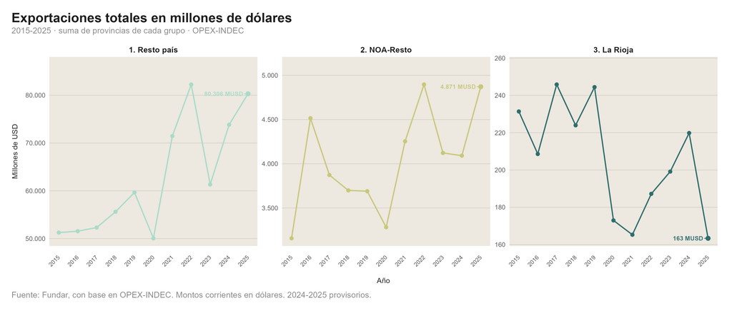

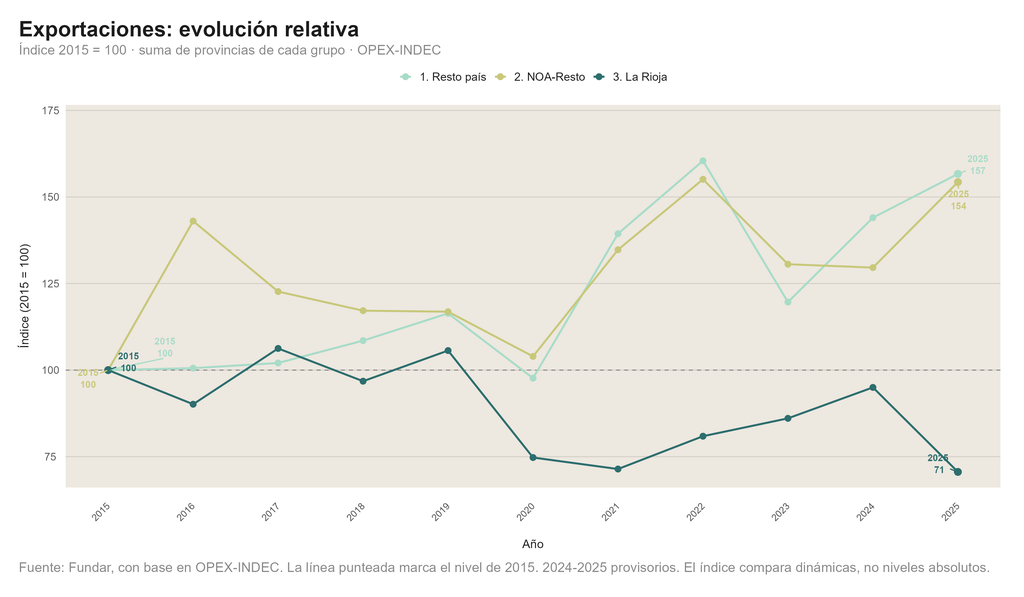

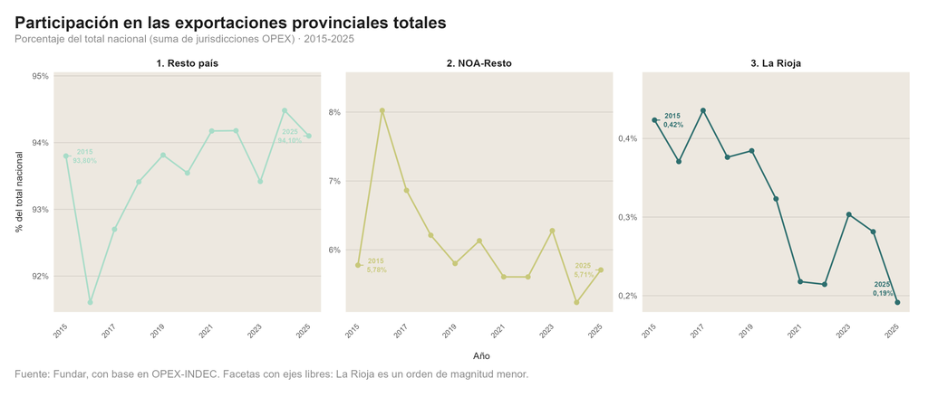

El gráfico de índice homologa la unidad de medida para los tres grupos (2015 = 100). Un valor mayor a 100 indica un nivel de exportaciones superior al de 2015; uno menor, una contracción. Al cierre de 2025: La Rioja (71), NOA-Resto (154) y resto del país (157).

## ¿En qué se concentra lo que exporta La Rioja?

La Rioja presenta una mayor concentración exportadora en comparación con el resto del NOA y el resto del país: sus tres principales rubros (preparados de hortalizas y frutas, grasas/aceites, papel/cartón) concentran aproximadamente el 77% del total publicado, frente a un ~ 36% registrado en los demás agregados territoriales. Esta elevada concentración incrementa la exposición de la provincia a impactos o fluctuaciones específicas en dichos sectores.

La estructura del perfil exportador exhibe marcadas diferencias regionales. El resto de las provincias del NOA integra productos químicos, cereales, oleaginosas y minería, complementados por hortalizas y tabaco. El resto del país responde al patrón clásico agroexportador y energético, encabezado por cereales, residuos de las industrias alimentarias, grasas y aceites, material de transporte y petróleo.

La Rioja se fundamenta en la agroindustria elaborada, aceites y papel/cartón, destacándose por la casi nula participación de los sectores cerealero y minero-energético en lo publicado. Que OPEX no publique un bloque minero desagregado no prueba cero minería (puede ser residual o confidencialidad).

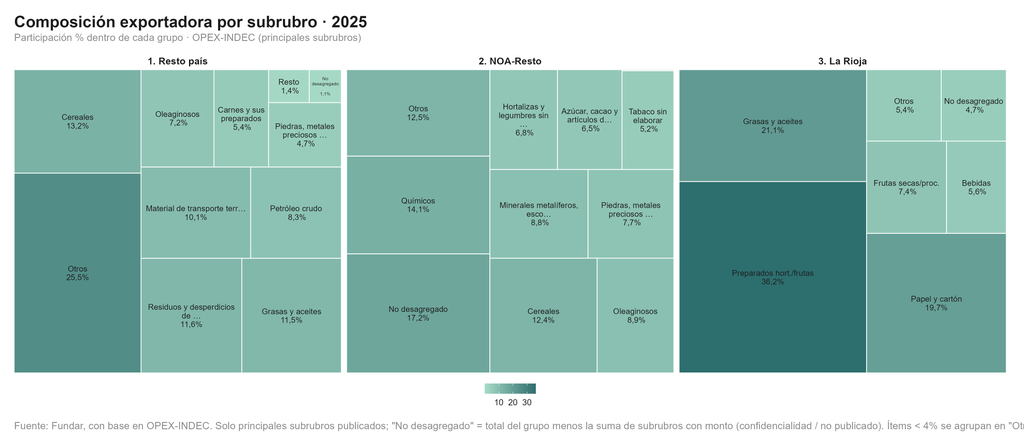

La etiqueta **“No desagregado”** del treemap corresponde a la diferencia entre el total provincial OPEX del grupo y la suma de los subrubros que sí reportan monto. No constituye un rubro publicado por OPEX; puede incluir ítems sujetos a confidencialidad u otras partidas no divulgadas. Los ítems con participación inferior al 4% se agrupan en **“Otros”**.

### Ficha metodológica

- **¿Qué mide?** El valor de los bienes con origen provincial despachados al exterior (millones de USD FOB en OPEX). En el Monitor: nivel, índice 2015 = 100, participación sobre las 24 jurisdicciones y composición por subrubros.
- **¿Para qué sirve?** Aproxima la inserción internacional de la economía provincial y el peso relativo de sus complejos exportadores.
- **¿Qué nos dice?**
  - *Si sube:* mayor venta externa (demanda, precios, volumen o mix de productos).
  - *Si baja:* menor inserción medida por OPEX (competitividad, precios, clima, o reasignación de origen en el registro).
- **Comportamiento esperado:** sensible a cotizaciones internacionales y a la estacionalidad agrícola; la serie anual suaviza parte de esa estacionalidad.
- **Unidad de medida:** millones de USD. El índice es adimensional (2015 = 100); el share es %.
- **Fórmula de cálculo:** agregación regional = **suma** de millones USD. Índice $100 \times X_t / X_{2015}$. Share = grupo / suma de totales de las 24 jurisdicciones × 100 (no usar la suma de subrubros parciales).
- **Fuente:** INDEC – OPEX — [página](https://www.indec.gob.ar/indec/web/Nivel4-Tema-3-2-79). Archivo típico: `sh_opex_principales_grubros_1993_XXXX.xls`. Scripts: `14_prep_exportaciones.R`, `14_prep_exportaciones_subrubros.R`, `14_prep_exportaciones_indice.R`, `14_exportaciones_*.R`.
- **Frecuencia:** anual (años recientes pueden ser provisorios).
- **Limitaciones:** solo bienes. Subrubros publicados no siempre cierran el 100%. Minería puede no aparecer desagregada para La Rioja. Hay subregistro posible si PyMEs consolidan o venden a exportadores de otras provincias: OPEX puede atribuir el origen según aduana o casa matriz. No confundir con SIPA.

## Cantidad de empresas

**¿Cuántas empresas hay en La Rioja?** Ficha metodológica.

Las empresas están en el centro de la vida económica: generan empleo, ingresos y capacidades productivas. La creación y destrucción de empresas está ligada a los ciclos económicos; el Monitor permite medir esa dinámica a escala local para orientar herramientas de contención y promoción.

Para el Gobierno de La Rioja, las empresas son un eje del desarrollo provincial: generan empleo, inversión y capacidades locales, y contribuyen a diversificar la estructura económica. En este marco, el Estado asume un rol activo, tanto acompañando al sector privado como interviniendo mediante empresas públicas en áreas estratégicas. Esta estrategia se complementa con políticas de apoyo al sector privado —financiamiento a PyMEs, promoción industrial, beneficios fiscales e infraestructura—. En un contexto nacional de retracción económica, la política provincial también busca sostener el entramado productivo, preservar el empleo y promover nuevas inversiones, articulando iniciativa pública y privada.

**Metodología.** Evolución de la cantidad de empresas en la provincia de La Rioja a partir de la Superintendencia de Riesgos del Trabajo (SRT), que contempla empresas públicas y privadas. La fuente considera empresa a cualquier persona física o jurídica con al menos un empleado registrado en relación de dependencia (se excluye personal doméstico / casas particulares). Serie por jurisdicción según ubicación de la persona trabajadora (UP), Cuadro 6.2. En los gráficos comparativos, NOA-Resto y Resto país son **suma** de empresas de las provincias del grupo (no promedio).

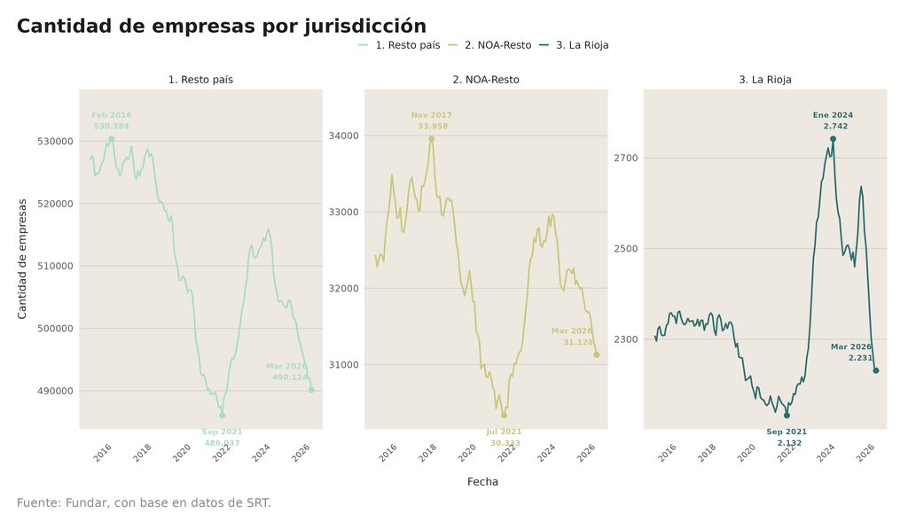

- En La Rioja hay actualmente 2.231 empresas formales (marzo 2026). Es decir, unidades productivas registradas que emplean al menos a un trabajador asalariado.
- Esta cifra marca una caída respecto al pico alcanzado en enero 2024, cuando había 2.742 empresas.
- El indicador registra una contracción mensual de 0,1% (3 empresas menos respecto de febrero 2026) y arrastra 9 meses consecutivos de caída mensual.
- Con respecto a marzo 2025, se registraron 265 empresas menos (baja de 10,6%). Con esta se acumulan 7 caídas interanuales consecutivas.
- Desde noviembre de 2023 (asunción del gobierno nacional) se perdieron 472 empresas, un 17,5% del total.
- Al pasar de 2.742 empresas (enero 2024) a 2.231 empresas (marzo 2026), la provincia registró una pérdida neta de 511 empresas. Esto representa una reducción del 18,6% de su tejido empresarial formal en un período de 26 meses.

**Distribución geográfica.** Dos factores resultan centrales para explicar la localización de las empresas en Argentina: la población y el nivel de actividad económica. En líneas generales, las jurisdicciones más pobladas (como Buenos Aires, Córdoba, Santa Fe y CABA) concentran también la mayor cantidad de empresas.

**Evolución reciente**

- 21 de las 24 provincias registran una caída intermensual.
- 23 de las 24 provincias registran una caída interanual.
- 23 de las 24 provincias registran una caída desde noviembre de 2023.
- En el último mes, crecieron 3 provincias.

### Ficha metodológica

- **¿Qué mide?** La cantidad total de firmas, empresas, sociedades o personas físicas formalmente registradas ante la seguridad social que declaran tener al menos un trabajador en relación de dependencia en la provincia de La Rioja.
- **¿Para qué sirve?** Indicador del dinamismo del tejido productivo formal. Permite monitorear la evolución de la actividad empresarial, evaluar el impacto de programas de promoción económica y analizar la capacidad del sector privado para generar empleo formal.
- **¿Qué nos dice?**
  - *Si sube:* mayor dinamismo empresarial, creación de unidades productivas, formalización, potencial aumento de oportunidades de empleo.
  - *Si baja:* reducción del tejido empresarial formal, cierre de establecimientos, posible desplazamiento hacia actividades no registradas.
- **Comportamiento esperado:** indicador estructural, con cambios graduales. Su evolución está asociada al contexto macroeconómico, el financiamiento, las expectativas de inversión y el clima de negocios.
- **Unidad de medida:** cantidad de empresas empleadoras registradas.
- **Fórmula de cálculo:** cantidad de empresas = suma de CUIT empleadores activos (según definición SRT). Agregado regional = suma de empresas de las provincias del grupo.
- **Fuente:** Superintendencia de Riesgos del Trabajo (SRT), serie histórica según jurisdicción — ubicación de la persona trabajadora (UP). Excel [Cuadro 6.2](https://www.srt.gob.ar/estadisticas/series/co/up/Serie_historica_Segun_Jurisdiccion%20-%20Ubicacion%20Persona%20Trabajadora%20-%20UP.xlsx). Scripts: `07_prep_cant_empresas.R`, `07_cant_empresas.R`.
- **Frecuencia:** mensual (el Excel SRT se actualiza con rezago; el prep puede cortar en `FECHA_HASTA`).
- **Limitaciones:** solo contempla empresas con al menos un trabajador asalariado registrado. No incluye autónomos, monotributistas sin empleados ni actividades informales. No informa tamaño de las empresas ni el empleo que generan.
- **Actualización:** borrar el xlsx en `data/raw_data/srt/`, correr el prep y el viz, knitear el RMD.

## Educación superior (+25)

**¿Qué proporción de la población de 25 años o más tiene estudios superiores completos?** Ficha metodológica.

La educación constituye un determinante central del desarrollo. A nivel individual, amplía capacidades, facilita el acceso a empleos de mayor calidad y contribuye a reducir desigualdades. A nivel colectivo, una población con mayores niveles educativos se asocia a mayores niveles de productividad, innovación y participación democrática.

Desde fines del siglo XIX, la educación argentina ocupó un lugar destacado en la agenda pública. La Ley 1420 de 1884 impulsó la expansión de la escuela primaria pública, gratuita y laica; la Reforma Universitaria de 1918 sentó las bases del sistema universitario público; en 1949 se estableció la gratuidad universitaria; y en 2006 se declaró la obligatoriedad de la educación secundaria.

Para el Gobierno de La Rioja, la educación constituye un derecho fundamental y un instrumento de inclusión, igualdad de oportunidades y movilidad social. Asimismo, representa una política pública estratégica orientada al desarrollo, la justicia social y la proyección de la provincia. En esa dirección, la Provincia impulsa políticas de ampliación y mejora de la infraestructura escolar, de conectividad y acceso a herramientas tecnológicas, de acompañamiento de trayectorias, de fortalecimiento de la educación técnica y la formación profesional, y de transformación de la escuela secundaria. El objetivo es ampliar las oportunidades educativas en todo el territorio y generar condiciones para que una proporción creciente de la población de La Rioja complete sus estudios y continúe su formación.

**Metodología.** El indicador es el porcentaje de población con estudios superiores completos (terciario o universitario) entre quienes tienen más de 25 años. No mide calidad educativa ni competencias. Se estima con EPH continua (INDEC) para el aglomerado La Rioja, y se compara con NOA-Resto y resto del país.

La Encuesta Permanente de Hogares (EPH) releva información de manera continua en los 31 aglomerados urbanos del país. En este informe, las estimaciones corresponden al aglomerado La Rioja y las cantidades absolutas se obtienen aplicando los factores de expansión provistos por el INDEC a los microdatos de la encuesta. Por lo tanto, representan una estimación de la población residente en el aglomerado y no de la totalidad de la provincia de La Rioja.

En los últimos 18 años, la población mayor de 25 años con estudios superiores completos en la Ciudad de La Rioja aumentó notoriamente.

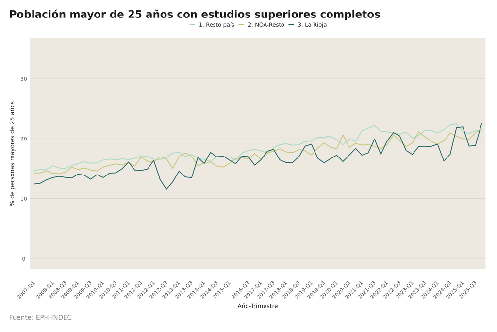

- En primer trimestre de 2007, el 12,4% de los adultos de la Ciudad de La Rioja contaba con estudios superiores completos. Al cuarto trimestre de 2025 esa cifra trepó al 22,6%.
- Casi una cuarta parte de la población adulta en la Ciudad de La Rioja tiene títulos superiores.
- Al cuarto trimestre de 2025, la Ciudad de La Rioja (22,6%) superó el promedio de los aglomerados del resto del país (21,3%) y se ubicó por encima de la media de los aglomerados del NOA (21,6%).
- En 2007: 1 de cada 8 adultos de la Ciudad de La Rioja tenía estudios superiores (12,4%); al cuarto trimestre de 2025: casi 1 de cada 4 (22,6%).

El aumento de la población mayor de 25 años con estudios superiores completos en la Ciudad de La Rioja es consistente con la mayor difusión de la educación media y superior durante el período. A modo de ejemplo, de acuerdo con los Censos Nacionales de Población y Vivienda de 1991 y 2022, el porcentaje de la población argentina mayor a 25 años con al menos secundario completo pasó del 24% al 47%. Debe tenerse en cuenta que se trata de un indicador meramente cuantitativo, y que no considera la calidad educativa. A su vez, este indicador no diferencia entre quienes recibieron escolarización a doble jornada y quienes lo hicieron con jornada simple.

### Ficha metodológica

- **¿Qué mide?** El porcentaje de la población de 25 años o más que finalizó estudios de nivel superior (terciario o universitario completo).
- **¿Para qué sirve?** Permite aproximar el nivel de capital humano disponible.
- **¿Qué nos dice?**
  - *Si sube:* más retención de egresados, acceso efectivo a la educación superior y mayor empleabilidad calificada.
  - *Si baja:* más deserción en estudios superiores, dificultades de acceso o finalización, o emigración de personas con título.
- **Comportamiento esperado:** indicador estructural, con cambios lentos.
- **Unidad de medida:** % de población de más de 25 años con estudios superiores completos.
- **Fórmula de cálculo:** población de +25 años con estudios superiores completos / población total de +25 años × 100.
- **Fuente:** EPH continua (INDEC). Scripts: `01_limpieza_eph.R`, `02_indicadores_eph_individuo.R`, `12_educ.R`.
- **Frecuencia:** trimestral.
- **Limitaciones:** el corte en mayores de 25 años puede omitir graduación temprana. No mide calidad educativa ni competencias. La EPH continua cubre el **aglomerado** La Rioja, no toda la provincia. En el CSV actual el denominador es la población EPH ponderada (todas las edades), no solo 25+.

## Trayectoria escolar

**¿Qué proporción de una cohorte escolar llega a 5° año del secundario?** Ficha metodológica.

Se denomina **cohorte teórica** al conjunto de alumnos que ingresan a **1° grado** en un año determinado y cuyo recorrido esperado, en el esquema educativo de La Rioja (7 años de primaria y 5 de secundaria), culmina en **5° año** al cabo de 12 años. El indicador aproxima cuántos, respecto de ese stock inicial, se encuentran matriculados en 5° año al final de ese plazo.

**Metodología.** Indicador acordado con Educación provincial. Se calcula como la relación entre la matrícula de **5° año** al final de la cohorte teórica y la matrícula de **1° grado** al inicio. Mide la llegada a 5° respecto del stock inicial; **no** equivale a egreso con título ni a un seguimiento nominal de los mismos alumnos (la migración, la repitencia y los reingresos afectan la lectura). Fuente: Relevamiento Anual (La Rioja).

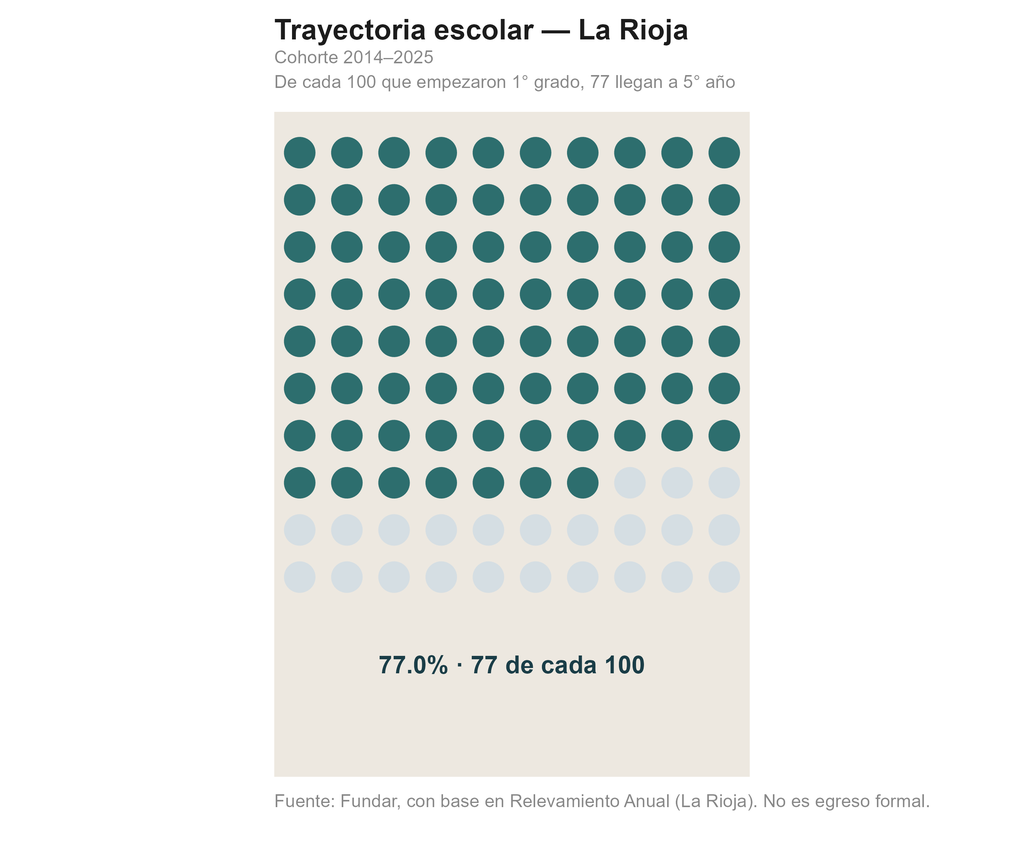

- En la cohorte 2014–2025, **de cada 100** que empezaron 1° grado, **77** llegan a 5° año (trayectoria 77,0%: de 6.912 a 5.325 alumnos).
- Por sexo: varones 70,7%; mujeres 83,7%.
- Por sector: estatal 72,2%; privado 111,5% (el privado puede superar 100% por ingresos netos a esa rama a lo largo de la cohorte).

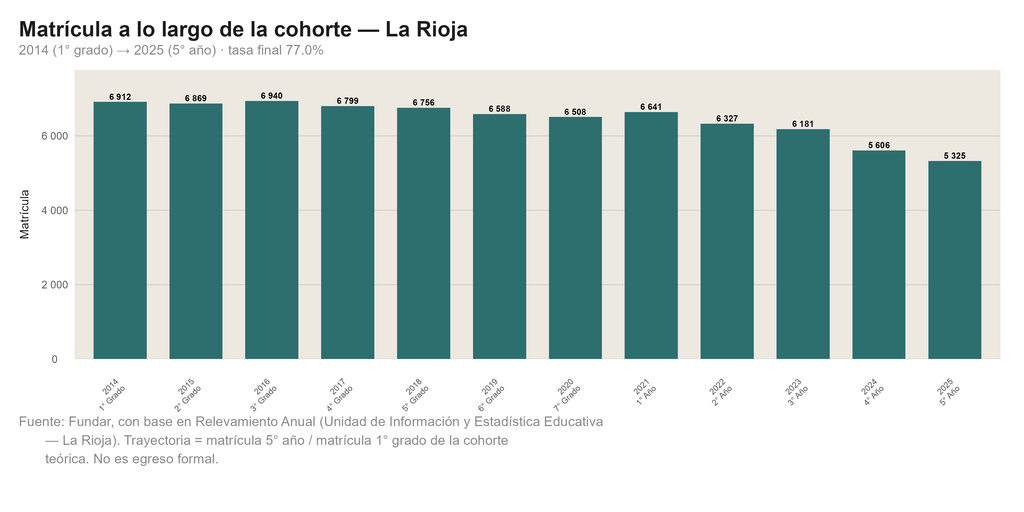

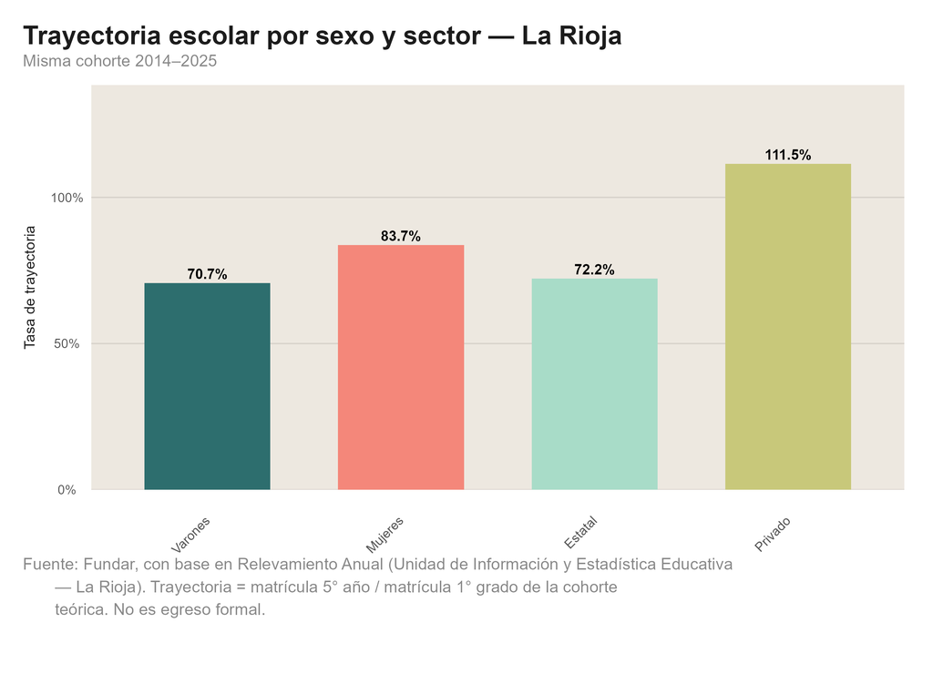

### Ficha metodológica

- **¿Qué mide?** Matrícula de 5° año / matrícula de 1° grado de la cohorte teórica.
- **Qué no mide:** egreso formal; panel nominal de los mismos alumnos; cobertura escolar; trayectoria desde el nivel inicial.
- **Fuente:** Relevamiento Anual (Unidad de Información y Estadística Educativa — La Rioja). Scripts: `18_prep_trayectoria_escolar.R`, `18_trayectoria_escolar.R`.
- **Cobertura:** solo La Rioja (no hay corte NOA/resto en esta fuente).
- **Frecuencia:** según actualización del Excel provincial.
- **Limitaciones:** migración, repitencia y reingresos afectan el ratio. Privado > 100% no implica “más egreso”, sino cambios de stock entre sectores.

## Pobreza por NBI (hogares y población)

**¿Cuántos hogares y personas tienen necesidades básicas insatisfechas (NBI) en la Ciudad de La Rioja?** Ficha metodológica.

En el Monitor, la aproximación a la pobreza estructural se realiza mediante el enfoque de **Necesidades Básicas Insatisfechas (NBI)**, y no mediante una medición de pobreza por ingresos. Un hogar presenta **NBI total** cuando registra al menos una privación en hacinamiento, vivienda, saneamiento, escolaridad o capacidad de subsistencia. El indicador se presenta como **pobreza por NBI**; no corresponde a un índice de pobreza multidimensional (IPM), al tratarse de una construcción metodológica distinta.

**Metodología.** Se estiman el % de hogares con NBI y el % de población en hogares con NBI, con EPH continua (INDEC), para el aglomerado La Rioja. Se compara con el NOA-Resto y resto del país. La lectura central es el NBI total; las subdimensiones muestran el tipo de privación dominante.

La Encuesta Permanente de Hogares (EPH) releva información de manera continua en los 31 aglomerados urbanos del país. En este informe, las estimaciones corresponden al aglomerado La Rioja y las cantidades absolutas se obtienen aplicando los factores de expansión provistos por el INDEC a los microdatos de la encuesta. Por lo tanto, representan una estimación de la población residente en el aglomerado y no de la totalidad de la provincia de La Rioja.

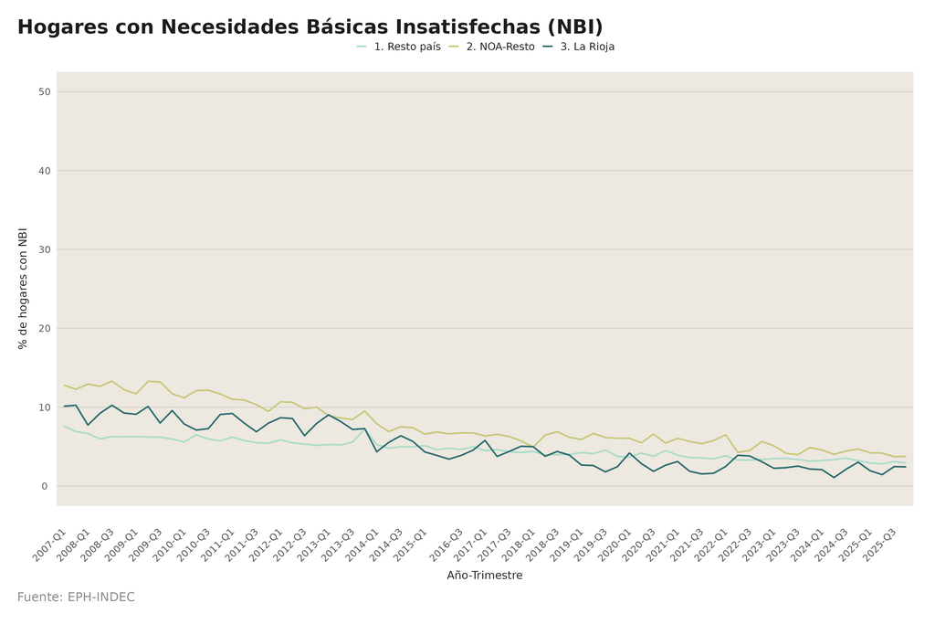

- Al cuarto trimestre de 2025, el 2,4% de los hogares del aglomerado La Rioja tenía al menos una NBI. Ese valor está por debajo del NOA-Resto (3,8%) y levemente por debajo del resto del país (2,9%).
- Comparación interanual (respecto al cuarto trimestre de 2024, con 3,0% de hogares con NBI): la incidencia bajó 0,6 puntos porcentuales.
- El NBI de hogares en la Ciudad de La Rioja está por debajo del NOA y en línea o por debajo del resto del país.
- En los últimos años (2021–2025) el NBI de hogares oscila en torno a 2–3%: es un indicador estructural, no un termómetro mes a mes.

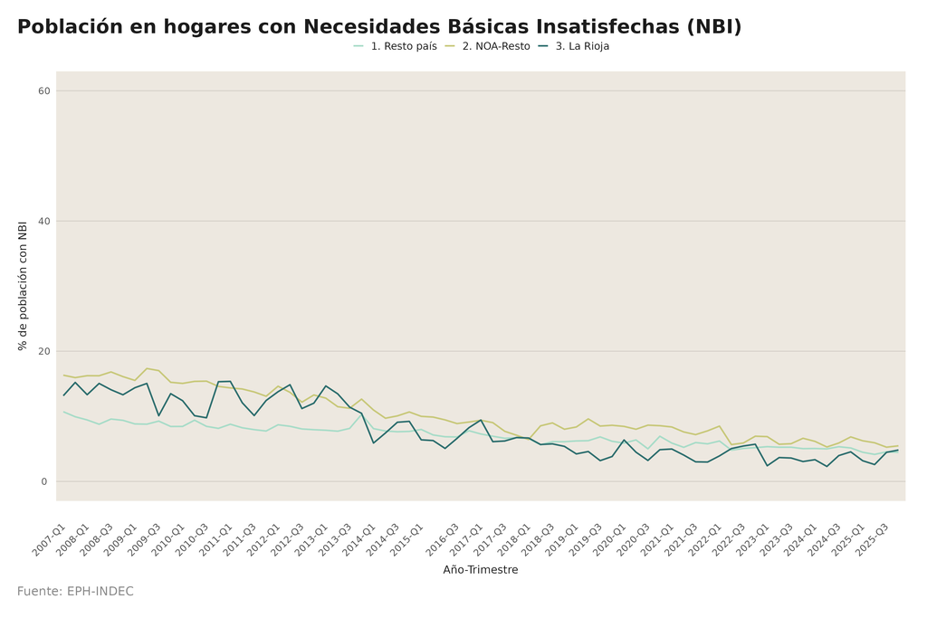

- En población, el 4,8% de las personas vive en hogares con NBI (5,5% en NOA-Resto; 4,5% en el resto del país).

### Ficha metodológica

- **¿Qué mide?** % de hogares y de población en hogares con al menos una Necesidad Básica Insatisfecha (NBI): privaciones estructurales en vivienda, saneamiento, hacinamiento, escolaridad y/o capacidad de subsistencia. Va más allá de la falta de ingreso monetario puntual.
- **¿Para qué sirve?** Ver si persisten carencias de infraestructura y condiciones de vida (baño, tipo de vivienda, hacinamiento, asistencia escolar, etc.) que un bono o un alza salarial de corto plazo no resuelven.
- **¿Qué nos dice?**
  - *Si sube:* más hogares/población con al menos una privación NBI.
  - *Si baja:* menos hogares/población con NBI (los cambios suelen ser lentos).
- **Comportamiento esperado:** indicador estructural. A diferencia de la pobreza por ingresos, no se mueve con un bono de fin de año o la inflación mensual.
- **Unidad de medida:** % de hogares (13a) o de población en hogares con NBI (13b).
- **Fórmula de cálculo:** hogares (o población) con al menos 1 NBI / total de hogares (o población) × 100.
- **Fuente:** EPH continua (INDEC). Scripts: `13a_nbi_hogares.R`, `13b_nbi_poblacion.R`.
- **Frecuencia:** trimestral.
- **Limitaciones:** la EPH continua solo cubre el aglomerado capital. No refleja el interior provincial ni zonas rurales. Conserva dimensiones críticas de privación, pero **no** es pobreza multidimensional / IPM.

# Trabajo e ingresos

El trabajo constituye la principal fuente de ingreso de los hogares. En este bloque se analizan el **desempleo**, el **empleo**, la **informalidad**, los **salarios** formales privados, los **puestos** asalariados privados y el **empleo público** por habitante, con el fin de describir cantidad, calidad y remuneración del empleo en La Rioja frente al NOA-Resto y al resto del país.

## Tasa de desempleo

**¿Cómo evolucionó el desempleo en la Ciudad de La Rioja?** Ficha metodológica.

**Metodología.** La tasa de desempleo indica el porcentaje de la población económicamente activa (PEA) que busca trabajo y no lo encuentra. Es un indicador de corto plazo del mercado laboral: conviene leerlo junto con la tasa de empleo y la informalidad.

La Encuesta Permanente de Hogares (EPH) releva información de manera continua en los 31 aglomerados urbanos del país. En este informe, las estimaciones corresponden al aglomerado La Rioja y las cantidades absolutas se obtienen aplicando los factores de expansión provistos por el INDEC a los microdatos de la encuesta. Por lo tanto, representan una estimación de la población residente en el aglomerado y no de la totalidad de la provincia de La Rioja.

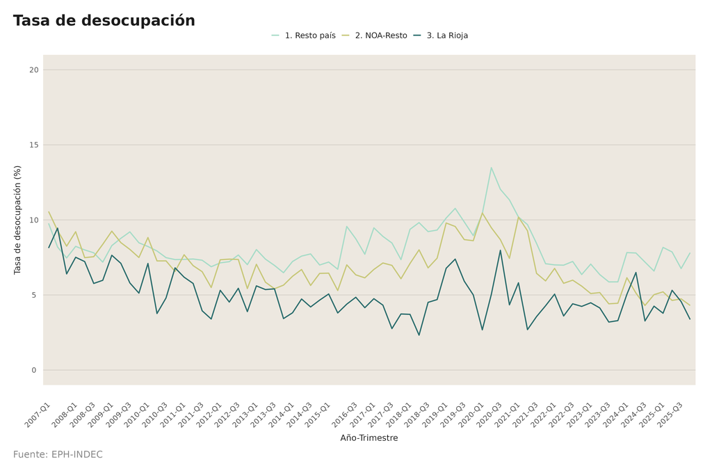

- Al cuarto trimestre de 2025, la tasa de desocupación del aglomerado La Rioja fue de 3,4%.
- En términos absolutos se estiman cerca de 4.000 personas desocupadas sobre una PEA de unos 118 mil.
- Comparación interanual (respecto al cuarto trimestre de 2024, con 4,3%): la desocupación bajó 0,9 puntos porcentuales.
- El pico de la serie reciente (desde 2015) fue el tercer trimestre de 2020 (8,0%). Desde entonces el nivel volvió a valores más bajos (por ejemplo 4,6% en el tercer trimestre de 2025 y 3,4% en el cuarto trimestre de 2025).

**Comparación con otros aglomerados**

- La tasa de desempleo es menor en la Ciudad de La Rioja que en el resto del país.
- Al cuarto trimestre de 2025, la tasa de desocupación del aglomerado La Rioja fue de 3,4%. Se ubicó por debajo del NOA-Resto (4,3%) y, sobre todo, del resto del país (7,8%).
- Con EPH continua la comparación corresponde a aglomerados. El patrón reciente sitúa a La Rioja por debajo del NOA y del resto del país. Para rankings de cobertura urbana más amplia se utiliza la EPH Total Urbano.

### Ficha metodológica

- **¿Qué mide?** El porcentaje de personas de la Población Económicamente Activa (PEA) que no tienen trabajo pero lo buscan activamente y están disponibles para comenzar a trabajar.
- **¿Para qué sirve?** Es el principal indicador de presión de la oferta laboral. Permite medir la incapacidad transitoria de la economía para absorber a la población que desea trabajar.
- **¿Qué nos dice?**
  - *Si sube:* pérdida de puestos de trabajo, cierre de empresas, o mayor necesidad de miembros del hogar de salir al mercado a buscar ingresos.
  - *Si baja:* mayor dinamismo económico (creación de empleo) u “ocultamiento” de una crisis si la gente se cansa de buscar y pasa a ser inactiva.
- **Comportamiento esperado:** depende del crecimiento del PBG, la inversión privada, la cantidad de empresas y el dinamismo de los sectores productivos.
- **Unidad de medida:** porcentaje (%) respecto de la PEA.
- **Fórmula de cálculo:** tasa de desempleo = población desocupada / PEA × 100.
- **Fuente de datos oficial:** EPH continua (INDEC). En el repo: `00_descarga_eph.R` → `01` → `02` → `04_desoc.R`.
- **Frecuencia de actualización:** trimestral.
- **Limitaciones:** mide el aglomerado capital, no el interior provincial. Una tasa baja puede coexistir con subocupación horaria elevada; conviene leerla junto con empleo e informalidad.

## Tasa de empleo

**¿Cómo evolucionó el empleo en la Ciudad de La Rioja?** Ficha metodológica.

Al analizar el mercado laboral, una variable central es la tasa de empleo, que indica el porcentaje de la población ocupada.

Para el Gobierno de La Rioja, el empleo constituye un objetivo central de la política económica y social: no se limita a la generación de ingresos, sino que se concibe como derecho e instrumento de inclusión y desarrollo. En una provincia con fuerte presencia del Estado y menor peso relativo del sector privado, sostener elevados niveles de ocupación resulta especialmente relevante.

La política provincial apunta a mantener el empleo existente y a ampliar oportunidades mediante apoyo al sector privado, financiamiento a PyMEs y emprendimientos, capacitación laboral y programas de inserción. El objetivo no se restringe a incrementar la cantidad de puestos, sino a promover un empleo más sostenible, formal y de mejor calidad, fortaleciendo la capacidad del sector privado para generar trabajo.

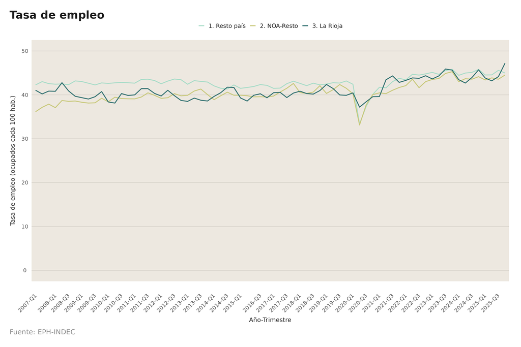

La tasa de empleo es mayor en la Ciudad de La Rioja y menor en los aglomerados del NOA.

- Al cuarto trimestre de 2025, la tasa de empleo en la Ciudad de La Rioja alcanzó el 47,2%, consolidando el registro más alto de toda la serie desde el inicio del 2007 (cuando se ubicaba en el 41,1%).
- La Ciudad de La Rioja se posicionó significativamente por encima de la media de los aglomerados del resto del país (45,0%) y superó el promedio de la región del NOA (44,5%).
- Al contrastar el dato con el mismo período del año anterior (cuarto trimestre de 2024, con 45,7%), la tasa de empleo creció 1,5 puntos porcentuales.

### Ficha metodológica

- **¿Qué mide?** El porcentaje de personas ocupadas respecto del total de la población.
- **¿Para qué sirve?** Permite evaluar la capacidad de la economía para generar empleo.
- **¿Qué nos dice?**
  - *Si sube:* una mayor proporción de la población se encuentra ocupada, lo que puede reflejar una mejora en el nivel de actividad económica o una mayor participación laboral.
  - *Si baja:* una menor proporción de la población tiene un empleo, lo que puede estar asociado a una desaceleración económica, una menor demanda de trabajo o cambios en la participación laboral.
- **Comportamiento esperado:** depende del crecimiento económico, la actividad y la participación laboral.
- **Unidad de medida:** porcentaje (%) de personas ocupadas sobre el total de la población (ocupados cada 100 habitantes).
- **Fórmula de cálculo:** tasa de empleo = población ocupada / población total × 100.
- **Fuente de datos oficial:** EPH continua (INDEC). En el repo: descarga vía paquete `eph` (`00_descarga_eph.R`) → `01` → `02` → `10_tasa_empleo.R`.
- **Frecuencia de actualización:** trimestral.
- **Limitaciones:** la tasa de empleo no refleja la calidad del empleo (formalidad, ingresos, estabilidad o horas). Debe analizarse junto con actividad y desocupación. En la EPH continua, La Rioja es el **aglomerado** capital, no toda la provincia.

## Informalidad (aportes)

**¿Qué tan informal es el empleo en la Ciudad de La Rioja?** Ficha metodológica.

La informalidad laboral constituye uno de los principales problemas del mercado de trabajo argentino. Suele asociarse a condiciones laborales precarias, bajos salarios y falta de derechos básicos.

Para el Gobierno de La Rioja, el trabajo constituye un derecho y uno de los pilares centrales de la política de desarrollo provincial. Desde esta perspectiva, el desafío no se limita a generar oportunidades laborales, sino también a avanzar hacia empleos con derechos, estabilidad, protección social e ingresos que permitan mejorar las condiciones de vida. La formalización laboral adquiere así una importancia estratégica, en tanto amplía el acceso a la seguridad social y fortalece trayectorias laborales de mayor calidad.

En esa línea, la Provincia implementa políticas de formación, capacitación, apoyo a emprendimientos, financiamiento y articulación con el sector productivo orientadas a facilitar la inserción laboral y el sostenimiento del empleo.

**Metodología.** La informalidad refiere a la situación de quienes trabajan sin un contrato formal ni acceso a la protección social, como la seguridad social o el seguro de salud. En el caso de los asalariados, una forma habitual de medirla consiste en verificar si el empleador realiza aportes a la seguridad social. De no hacerlo, ese trabajador no tendrá derecho, por ejemplo, a una jubilación en el futuro. Cabe aclarar que estos datos corresponden únicamente a los asalariados, ya que excluyen a los trabajadores independientes.

La Encuesta Permanente de Hogares (EPH) releva información de manera continua en los 31 aglomerados urbanos del país. En este informe, las estimaciones corresponden al aglomerado La Rioja y las cantidades absolutas se obtienen aplicando los factores de expansión provistos por el INDEC a los microdatos de la encuesta. Por lo tanto, representan una estimación de la población residente en el aglomerado y no de la totalidad de la provincia de La Rioja.

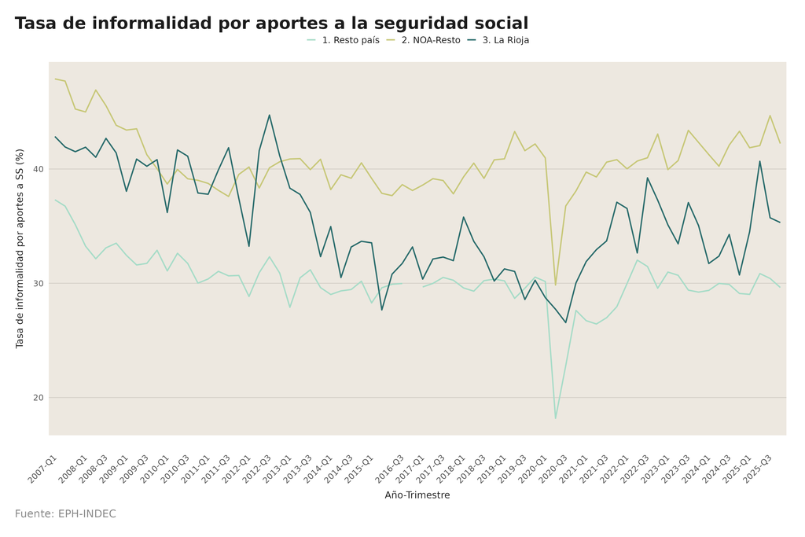

- En la Ciudad de La Rioja, se estima que 32.369 personas asalariadas trabajan en la informalidad. Sobre un total estimado de 91.657 trabajadores asalariados, esto equivale al 35,3%. Es decir, aproximadamente uno de cada tres asalariados no recibe aportes a la seguridad social por parte de su empleador.
- Comparación interanual (respecto al cuarto trimestre de 2024): se observó un incremento de 4,6 puntos porcentuales, ya que en el mismo trimestre del año anterior la tasa se situaba en un 30,7% (con 26.706 asalariados informales).
- La informalidad en la Ciudad de La Rioja es hoy más baja que hace 18 años. En 2025, la informalidad entre asalariados fue del 35,3%, 6,6 puntos menos que a mediados de 2007 (41,9%).

**¿Cómo se compara con otras regiones?**

La informalidad en la Ciudad de La Rioja es menor que en los aglomerados de las provincias del norte pero mayor que en los aglomerados del resto del país.

- En la Ciudad de La Rioja, el 35,3% de los asalariados y asalariadas trabaja de manera informal.
- En el resto de los aglomerados de las provincias del NOA el 42,2% de los asalariados trabaja de manera informal.
- En el resto de los aglomerados del país el 29,6% de los asalariados trabaja de manera informal.

### Ficha metodológica

- **¿Qué mide?** La proporción de trabajadores asalariados que no realizan aportes jubilatorios a través de su empleo principal.
- **¿Para qué sirve?** Permite monitorear la calidad del empleo, identificar situaciones de precariedad laboral y orientar políticas de formalización del trabajo.
- **¿Qué nos dice?**
  - *Si sube:* mayor precarización laboral, menor acceso a derechos laborales y protección social, menor cobertura previsional futura.
  - *Si baja:* mayor formalización del empleo, incremento de la protección social de los trabajadores.
- **Comportamiento esperado:** suele presentar cambios graduales; está influenciado por el ciclo económico, la dinámica del mercado laboral y las políticas de fiscalización y formalización.
- **Unidad de medida:** porcentaje (%) de asalariados sin descuento jubilatorio sobre el total de asalariados.
- **Fórmula de cálculo:** tasa de informalidad = (asalariados sin descuento jubilatorio / total de asalariados) × 100.
- **Fuente de datos oficial:** Encuesta Permanente de Hogares (INDEC). En el repo: `00` → `01` → `02` → `09a_informalidad_aportes.R`.
- **Frecuencia de actualización:** trimestral.
- **Limitaciones:** con EPH continua, la información representa al **aglomerado** La Rioja y no a toda la provincia. Solo asalariados (excluye independientes). Un ranking por provincia urbana ampliada requeriría EPH Total Urbano.

## Salarios formales (privado SIPA)

**¿Cómo se ubican los salarios formales de La Rioja?** Ficha metodológica.

El análisis de los salarios formales puede abordarse a partir de dos fuentes complementarias. Por un lado, el Sistema Integrado Previsional Argentino (SIPA) ofrece la remuneración promedio del sector privado registrado, con cobertura provincial y frecuencia mensual. Por otro, la EPH releva ingresos de personas asalariadas registradas (público y privado), lo que resulta útil para separar el sector estatal y, con IPC, observar variaciones reales (en la EPH continua, el dato de La Rioja corresponde al aglomerado capital).

**Metodología.** En esta sección del Monitor se emplean los registros del SIPA (OEDE). En primer lugar, se presenta la serie en valores nominales (pesos corrientes), útil para elaborar rankings entre provincias en un mismo mes y para comparar a La Rioja con el promedio simple del resto del NOA y del país. En segundo lugar, se expone la serie deflactada por el IPC, orientada a evaluar la tendencia y la evolución del poder de compra a lo largo del tiempo.

Dado que los datos del SIPA se estructuran “por todo concepto”, los meses de junio y diciembre incorporan el Sueldo Anual Complementario (SAC), lo que genera un marcado patrón estacional en la serie mensual. Para neutralizar ese comportamiento recurrente, la serie fue desestacionalizada y posteriormente deflactada mediante el IPC nacional, a fin de analizar el salario en términos reales. El resultado se expresa como un índice con base en enero de 2025 = 100: los valores superiores a 100 indican un mayor poder de compra respecto de esa fecha; los inferiores, una disminución.

**¿Qué nos dice el último dato nominal (Sep-2025)?**

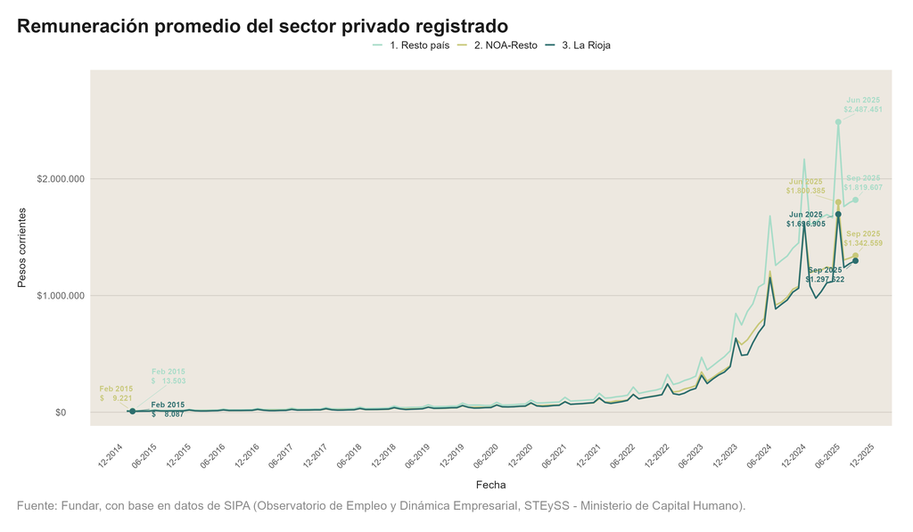

- En La Rioja la remuneración promedio del privado registrado fue de $1.297.622.
- Eso la ubica en el puesto 19 de las 24 provincias.
- NOA-Resto ≈ $1.342.559; resto del país ≈ $1.819.607.

**¿Qué nos dice la serie en términos reales?**

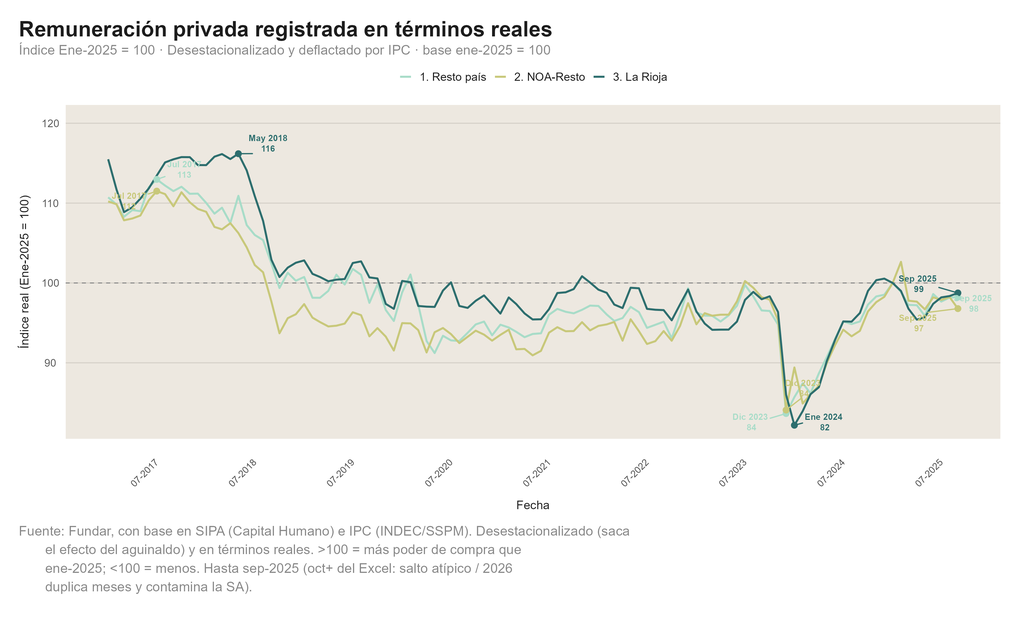

**Fuente.** SIPA/OEDE + IPC INDEC/SSPM. Scripts: prep/viz nominal; `03_prep_salarios_privados_SIPA_indice.R` → `03_salarios_privados_SIPA_indice.R`.

### Ficha metodológica

- **¿Qué mide?** La remuneración bruta promedio percibida por el conjunto de trabajadores en relación de dependencia formalizada (con aportes jubilatorios y de seguridad social). En esta sección del Monitor: sector **privado registrado** (SIPA/OEDE).
- **¿Para qué sirve?** Permite observar el poder adquisitivo de los hogares registrados y la capacidad de consumo del mercado provincial.
- **¿Qué nos dice?**
  - *Si sube:* mejora real de poder adquisitivo frente a la inflación, tracción del comercio interno de La Rioja y mejor bienestar de las familias.
  - *Si baja:* licuación de ingresos por procesos inflacionarios severos, retracción del consumo local y aumento del empleo pobre.
- **Comportamiento esperado:** actualización escalonada por paritarias y bonos. Presenta “picos” estacionales en los meses de pago de aguinaldos (junio y diciembre).
- **Unidad de medida:** pesos argentinos corrientes; y, para la lectura de tendencia, índice real (ene-2025 = 100) tras desestacionalizar y deflactar por **IPC nacional** (INDEC/SSPM).
- **Fórmula de cálculo:** (i) nominal = remuneración promedio SIPA;
  2. real SA = serie desestacionalizada / IPC nacional, indexada en ene-2025 = 100.
- **Fuente de datos oficial:** SIPA / OEDE (Ministerio de Capital Humano) — remuneraciones del sector privado registrado. IPC nacional para el índice real.
- **Frecuencia de actualización:** mensual (SIPA). La serie del Monitor se presenta hasta el último mes validado del procesamiento (hoy sep-2025), ante inconsistencias en meses posteriores del Excel SIPA.
- **Limitaciones:** al basarse en registros administrativos formales (SIPA), esta métrica no captura ingresos de cuentapropistas informales, trabajadores de cooperativas ni asalariados no registrados. No confundir con la EPH (aglomerado en la continua) ni con liquidaciones del sector público. El detalle operativo del corte (`FECHA_HASTA`) está en el encabezado de `03_prep_salarios_privados_SIPA_indice.R`.

## Puestos asalariados privados

**¿Cómo evolucionó el empleo privado registrado en La Rioja?** Ficha metodológica.

Los puestos asalariados privados registrados (SIPA / OEDE) miden el empleo formal privado declarado. Constituyen un indicador de coyuntura del mercado de trabajo privado, distinto del empleo público (EPH) y de la cantidad de empresas (SRT).

**Metodología.** Se utiliza la serie mensual en miles de puestos, sin estacionalidad (hoja A.5.2 del reporte de trabajo registrado). La comparación regional se construye con la **suma** de puestos de las provincias del NOA-Resto y del resto del país.

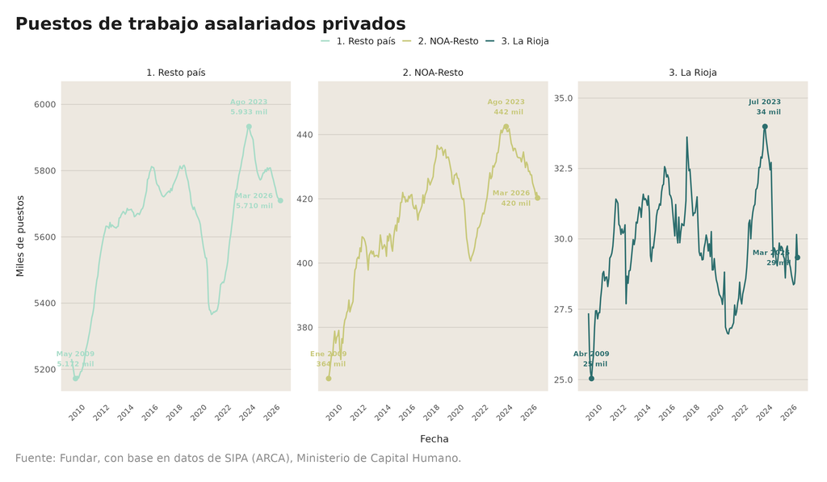

- En marzo 2026, La Rioja tenía 29,3 mil puestos asalariados privados registrados.
- En el mismo mes, el NOA-Resto sumaba 420,3 mil puestos y el resto del país 5.709,7 mil (suma de provincias de cada grupo).
- Respecto de marzo 2025 (28,6 mil), creció 2,5%.

### Ficha metodológica

- **¿Qué mide?** Puestos de trabajo asalariados privados registrados (miles).
- **Fórmula de cálculo:** miles de puestos por provincia (SIPA A.5.2). Agregado regional = **suma** de puestos de las provincias del grupo.
- **Fuente:** SIPA / OEDE — reporte de trabajo registrado (hoja A.5.2, sin estacionalidad). Scripts: `05_prep_puestos_asalariados_privados.R`, `05_puestos_asalariados_privados.R`.
- **Frecuencia:** mensual.
- **Limitaciones:** solo privado registrado (no incluye no registrados ni monotributo puro). La suma provincial puede diferir levemente del total nacional por el método de desestacionalización (nota SIPA). En el gráfico, el agregado regional es la **suma** de puestos de las provincias del grupo.

## Empleados públicos cada 1.000 habitantes

**¿Cuál es la magnitud del empleo público en La Rioja?** Ficha metodológica.

El empleo público es un fenómeno transversal al territorio nacional y a los tres niveles de gobierno: Nación, provincias y municipios. Según el INDEC, en 2024 Argentina registraba 3,8 millones de puestos en el sector público, equivalentes al 17% del empleo total.

Por empleo público se entiende a las personas que trabajan como asalariadas en una institución del Estado —nacional, provincial o municipal—, en cualquiera de sus poderes. Una proporción elevada de ese empleo se concentra en administración pública y defensa, enseñanza y salud.

En La Rioja, el empleo público ocupa un lugar central en la estructura económica provincial. Por su peso relativo, constituye uno de los principales sostenes del ingreso de los hogares y de la demanda interna: los salarios del sector estatal se destinan mayoritariamente al consumo local y dinamizan el comercio y los servicios. Así, además de garantizar el funcionamiento del Estado y la prestación de servicios esenciales, cumple un rol relevante en el circuito económico provincial.

Esa relevancia se inserta en una estructura productiva con asimetrías regionales y en un sector privado que aún no alcanza la escala suficiente para absorber toda la demanda laboral. En ese contexto, el Estado cumple una doble función: sostiene el empleo y los servicios públicos en el territorio e impulsa políticas de diversificación productiva y fortalecimiento del sector privado —promoción industrial, financiamiento, infraestructura y apoyo a PyMEs—. El objetivo es ampliar el empleo privado sin debilitar el rol económico y social del empleo público.

**Metodología.** El indicador mide empleados públicos cada 1.000 habitantes: asalariados ocupados del sector estatal por cada 1.000 habitantes de la población urbana. Se elabora con la EPH Total Urbano (INDEC), relevada en el tercer trimestre de cada año. El numerador corresponde a ocupados asalariados del sector público y el denominador a la población urbana total de la muestra, ambos ponderados. En el Monitor se estima a partir de los asalariados ocupados cuyo establecimiento es estatal (`PP04A`). El indicador representa a la población **urbana** y no equivale a un padrón administrativo de planta.

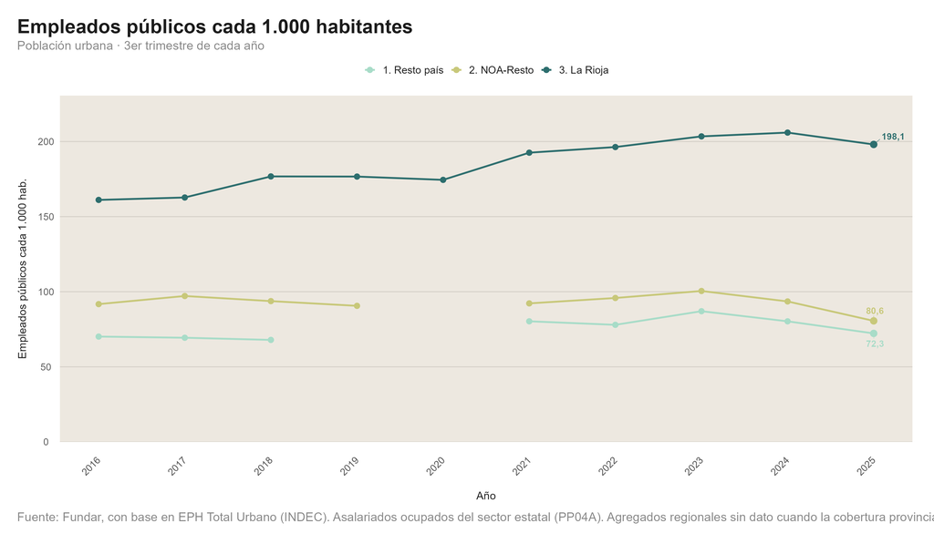

- En La Rioja se observa de manera persistente un nivel de empleo público urbano superior al del resto de las provincias del NOA y al del resto del país. En 2025 se estiman 198 empleados públicos cada 1.000 habitantes en la población urbana de La Rioja, frente a 81 en el NOA-Resto y 72 en el resto del país.
- Entre 2016 y 2024 la serie de La Rioja registra una trayectoria ascendente (de aproximadamente 161 a un máximo cercano a 206), con una baja en 2025 (198). En el mismo período, NOA-Resto y resto del país se mantienen en niveles sustancialmente inferiores y con mayor estabilidad.

**Comparación en el NOA**

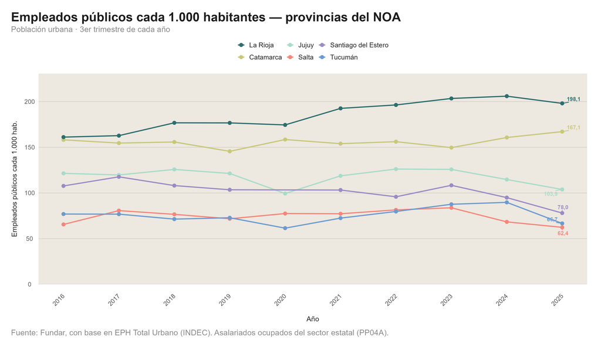

- Dentro del NOA, La Rioja también lidera el ranking provincial: en 2025 la sigue Catamarca (~167), luego Jujuy (~104), y más abajo Santiago del Estero, Tucumán, Salta. Esto refuerza que el fenómeno no es solo “regional”, sino particularmente marcado en La Rioja.

El indicador no evalúa por sí solo si el empleo público es “alto” o “bajo” en términos normativos: su utilidad radica en contextualizar la magnitud del sector estatal frente a otras jurisdicciones y a lo largo del tiempo. Una lectura complementaria consiste en cruzarlo con empleo privado formal, salarios y estructura productiva.

**Composición por rama**

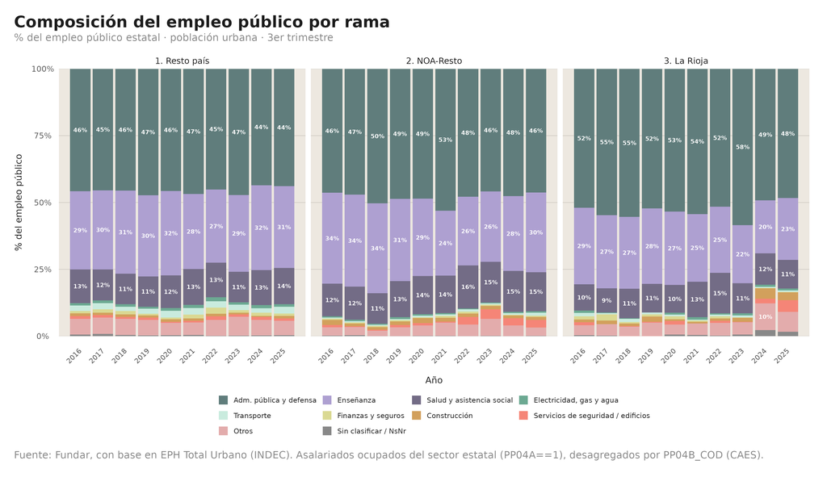

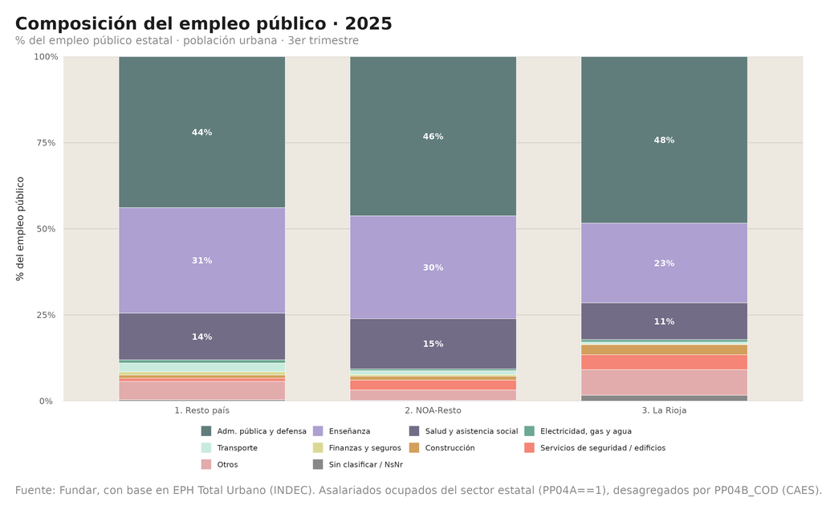

- Por rama (asalariados estatales, 2025): Adm. pública y defensa (48,3%), Enseñanza (23,1%) y Salud y asistencia social (10,7%).

### Ficha metodológica

- **¿Qué mide?** Asalariados ocupados del sector estatal por cada 1.000 habitantes de la población urbana.
- **¿Para qué sirve?** Observar el peso relativo del empleo público y compararlo con el NOA y el resto del país; discutir tamaño del sector público y su evolución.
- **Unidad de medida:** empleados públicos cada 1.000 habitantes (población urbana EPH Total Urbano).
- **Fórmula de cálculo:** $1000 \times$ asalariados públicos ponderados / población ponderada (`PONDERA`). Establecimiento estatal (`PP04A`).
- **Fuente:** EPH Total Urbano (INDEC), 3er trimestre. Raw: `data/raw_data/eph_total_urbano_*/`. Scripts: `06_prep_empleados_publicos_eph_tu.R`, `06_empleados_publicos.R`; composición: `06_prep_empleados_publicos_composicion.R`.
- **Frecuencia:** anual (3T).
- **Limitaciones:** representa población **urbana**, no un padrón de planta. Incluye empresas estatales si el establecimiento es estatal; la EPH no separa administración de empresa pública. No es, por sí solo, un juicio normativo sobre el “tamaño” del Estado.

# Fichas metodológicas

Esta sección reúne el índice de fichas metodológicas. Cada ficha figura debajo de su indicador en el cuerpo del informe, en el mismo orden que el listado siguiente.

Material de referencia para talleres y documentos Word: `informe/analisis_indicadores_provincia/fichas_Indicadores.pptx`. Instrucciones de actualización del Monitor: `README.md`.

## PIB / PBG provincial

Ver ficha metodológica.

## Recursos propios / recursos totales

Ver ficha metodológica.

## Resultado fiscal (APNF)

Ver ficha metodológica.

## % del PBG industrial

Ver ficha metodológica.

## Exportaciones

Ver ficha metodológica.

## Cantidad de empresas

Ver ficha metodológica.

## Educación superior (+25)

Ver ficha metodológica.

## Trayectoria escolar

Ver ficha metodológica.

## Pobreza por NBI (hogares y población)

Ver ficha metodológica.

## Tasa de desempleo

Ver ficha metodológica.

## Tasa de empleo

Ver ficha metodológica.

## Informalidad (aportes)

Ver ficha metodológica.

## Salarios formales (privado SIPA)

Ver ficha metodológica.

## Puestos asalariados privados

Ver ficha metodológica.

## Empleados públicos cada 1.000 habitantes

Ver ficha metodológica.

# Reproducibilidad

Ver el **README** del repositorio para fichas completas de update, qué no modificar (corte NOA-Resto, fórmulas, tema) y el orden del pipeline.

```r
rmarkdown::render("informe/monitor_la_rioja.Rmd")
```